# Palavras e gêneros dos best sellers, por Luiz Guilherme

Este relatório busca identificar quais gêneros em geral são mais e melhor avaliados pelos leitores, bem como entender, a partir dos resumos dos livros, as palavras - e consequentemente temas - que causam maior interesse.

## Carregamento dos dados

Foram utilizadas duas bases em conjunto, ambas disponíveis inicialmente no portal Kaggle.com:

- booksumaries.csv: contém resumos e dados básicos de 16.559 livros, extraídos da Wikipedia e disponibilizados na plataforma em abril/2018. Possui 7 colunas:

```
## [1] 16559     7
```

- books.csv: contém avaliações e dados básicos de 10.000 livros. Possui 23 colunas:

```
## [1] 10000    23
```

Inicialmente foi feita a preparação dos dados da primeira base, transformando principalmente a coluna de gêneros, que continha todos os gêneros por livro divididos por vírgulas e foi dividida em quatro novas.

```
## [1] 12841    11
```

```
## 'data.frame':    12841 obs. of  11 variables:
##  $ wikipedia_id    : int  620 843 986 2080 2152 2890 4081 4082 4386 6020 ...
##  $ freebase_id     : Factor w/ 16559 levels "/m/0_3ph","/m/0_bnp",..: 16320 16475 16505 16554 16556 29 195 196 243 459 ...
##  $ book_title      : Factor w/ 16277 levels "'Art'","'Tis Pity She's a Whore",..: 1007 137 13246 215 793 558 1615 1614 1756 2544 ...
##  $ book_author     : Factor w/ 4715 levels "","'Asta Bowen",..: 1558 296 92 4487 1309 4464 2501 2501 1 1883 ...
##  $ publication_date: Factor w/ 2640 levels "","0398","1005",..: 394 511 401 1 329 548 1263 1218 1 604 ...
##  $ genres          : chr  "Roman a clef,Satire,Children's literature,Speculative fiction,Fiction" "Science Fiction,Novella,Speculative fiction,Utopian and dystopian fiction,Satire,Fiction" "Existentialism,Fiction,Absurdist fiction,Novel" "Hard science fiction,Science Fiction,Speculative fiction,F…
##  $ genre_1         : chr  "Roman a clef" "Science Fiction" "Existentialism" "Hard science fiction" ...
##  $ genre_2         : chr  "Satire" "Novella" "Fiction" "Science Fiction" ...
##  $ genre_3         : chr  "Children's literature" "Speculative fiction" "Absurdist fiction" "Speculative fiction" ...
##  $ genre_4         : chr  "Speculative fiction" "Utopian and dystopian fiction" "Novel" "Fantasy" ...
##  $ summary         : Factor w/ 16532 levels "- --&#62; &#60;!-",..: 7343 1256 14809 12481 10282 3926 6450 2129 10030 14316 ...
```

Neste ponto, após as transformações, a dataframe book_summaries passou a conter 12.841 observações e 11 variáveis, conforme exibido acima.

Em seguida, as colunas título do livro e autor do livro foram tratadas para possibilitar join posterior:

```
##   wikipedia_id freebase_id                     book_title
## 1          620     /m/0hhy                    Animal Farm
## 2          843     /m/0k36             A Clockwork Orange
## 3          986     /m/0ldx                     The Plague
## 5         2080     /m/0wkt           A Fire Upon the Deep
## 6         2152     /m/0x5g All Quiet on the Western Front
## 7         2890    /m/011zx           A Wizard of Earthsea
##            book_author publication_date
## 1        George Orwell       1945-08-17
## 2      Anthony Burgess             1962
## 3         Albert Camus             1947
## 5         Vernor Vinge
## 6 Erich Maria Remarque       1929-01-29
## 7    Ursula K. Le Guin             1968
##                                                                                     genres
```

[output cut: 27 more lines]

A segunda base foi então preparada, esta com os dados de avaliações por livro. Esta base sofreu basicamente as mesmas transformações que a primeira:

```
##   book_id goodreads_book_id best_book_id  work_id books_count      isbn
## 1       1           2767052      2767052  2792775         272 439023483
## 2       2                 3            3  4640799         491 439554934
## 3       3             41865        41865  3212258         226 316015849
## 4       4              2657         2657  3275794         487  61120081
## 5       5              4671         4671   245494        1356 743273567
## 6       6          11870085     11870085 16827462         226 525478817
##         isbn13                      authors original_publication_year
## 1 9.780439e+12              Suzanne Collins                      2008
## 2 9.780440e+12 J.K. Rowling, Mary GrandPrÃ©                      1997
## 3 9.780316e+12              Stephenie Meyer                      2005
## 4 9.780061e+12                   Harper Lee                      1960
## 5 9.780743e+12          F. Scott Fitzgerald                      1925
## 6 9.780525e+12                   John Green                      2012
##                             original_title
```

[output cut: 48 more lines]

Foi feito o join entre os dois dataframes tratados, excluindo-se as colunas desnecessárias, de forma a obter um resultante com 1943 observações e 20 variáveis:

```
## [1] 1943   20
```

```
##             book_title       book_author original_publication_year
## 1   A Clockwork Orange   Anthony Burgess                      1962
## 2 A Fire Upon the Deep      Vernor Vinge                      1992
## 3 A Wizard of Earthsea Ursula K. Le Guin                      1968
## 4                Crash     J. G. Ballard                      1973
## 5     Children of Dune     Frank Herbert                      1976
## 6    Chapterhouse Dune     Frank Herbert                      1985
##   language_code
## 1           eng
## 2           eng
## 3         en-US
## 4         en-CA
## 5           eng
## 6           eng
##                                                                                     genres
```

[output cut: 34 more lines]

Acrescentou-se três novas colunas, todas a partir do gênero principal:

- genre_1_median_rating: mediana das avaliações médias;
- genre_1_mean_ratings_count: média das quantidades de avaliações observadas;
- genre_1_freq: frequência do genero na base.

Também criou-se uma lista ordenada decrescentemente por genre_1_mean_ratings_count, com todos os gêneros únicos. Observa-se que há 88 gêneros distintos na dataframe books:

```
## [1] 88  4
```

```
## # A tibble: 6 x 4
##   genre_1          genre_1_median_rat~ genre_1_mean_ratings_~ genre_1_freq
##   <chr>                          <dbl>                  <dbl>        <int>
## 1 First-person na~                3.79               2120637             1
## 2 Vampire fiction                 3.96               1225340.            4
## 3 Anti-war                        3.98                582515             1
## 4 Sea story                       3.73                574328             1
## 5 Conspiracy fict~                4.19                525976             1
## 6 Ghost story                     4.02                441396             1
```

# Seção de Gráficos Univariados e Análise Univariada

### Qual é a estrutura do conjunto de dados?

```
## [1] 1943   23
```

```
## Classes 'tbl_df', 'tbl' and 'data.frame':    1943 obs. of  22 variables:
##  $ book_title                : Factor w/ 16277 levels "'Art'","'Tis Pity She's a Whore",..: 137 215 558 2544 2216 2146 10620 3769 4346 4476 ...
##  $ book_author               : Factor w/ 4715 levels "","'Asta Bowen",..: 296 4487 4464 1883 1424 1424 2289 3663 1109 1424 ...
##  $ original_publication_year : num  1962 1992 1968 1973 1976 ...
##  $ language_code             : Factor w/ 26 levels "","ara","dan",..: 8 8 7 5 8 8 8 23 8 8 ...
##  $ genres                    : chr  "Science Fiction,Novella,Speculative fiction,Utopian and dystopian fiction,Satire,Fiction" "Hard science fiction,Science Fiction,Speculative fiction,Fantasy,Fiction" "Children's literature,Fantasy,Speculative fiction,Bildungsroman,Fiction" "Speculative fiction,…
##  $ genre_1                   : chr  "Science Fiction" "Hard science fiction" "Children's literature" "Speculative fiction" ...
##  $ genre_2                   : chr  "Novella" "Science Fiction" "Fantasy" "Fiction" ...
##  $ genre_3                   : chr  "Speculative fiction" "Speculative fiction" "Speculative fiction" "Novel" ...
##  $ genre_4                   : chr  "Utopian and dystopian fiction" "Fantasy" "Bildungsroman" NA ...
##  $ summary_part              : chr  " Alex, a teenager living in ne" " The novel posits that space a" " Ged is a young boy on Gont, o" " The story is told through the" ...
##  $ average_rating            : num  3.98 4.13 3.99 3.58 3.9 3.89 4.1 3.97 4.26 3.81 ...
##  $ ratings_count             : int  431195 37986 155042 13217 74133 34822 124876 570498 14750 45608 ...
##  $ work_ratings_count        : int  454391 40508 167058 15187 79736 37155 134263 1176240 16378 51891 ...
##  $ work_text_reviews_count   : int  9958 1801 5357 925 1374 552 3170 30694 1203 1069 ...
##  $ ratings_1                 : int  14741 654 3253 825 861 676 1250 28366 166 1070 ...
##  $ ratings_2                 : int  24244 1672 9210 1804 4425 2612 4327 64289 526 4298 ...
##  $ ratings_3                 : int  84863 6494 34737 3900 20138 9170 23669 238242 2267 13741 ...
##  $ ratings_4                 : int  163488 14506 58618 5091 30723 12496 55302 426292 5352 17028 ...
##  $ ratings_5                 : int  167055 17182 61240 3567 23589 12201 49715 419051 8067 15754 ...
##  $ genre_1_median_rating     : num  4 4.09 3.98 4.04 4 ...
##  $ genre_1_mean_ratings_count: num  142597 38157 95866 89774 142597 ...
##  $ genre_1_freq              : int  286 6 200 225 286 286 202 286 98 286 ...
```

```
##             book_title            book_author   original_publication_year
##  Twilight        :   3   Terry Pratchett:  34   Min.   :1813
##  A Clash of Kings:   2   Dean Koontz    :  32   1st Qu.:1982
##  Broken          :   2   Agatha Christie:  30   Median :1998
##  City of Bones   :   2   Stephen King   :  28   Mean   :1988
##  Dark Fire       :   2   Anne Rice      :  18   3rd Qu.:2005
##  Ender's Game    :   2   John Grisham   :  18   Max.   :2012
##  (Other)         :1930   (Other)        :1783
##  language_code     genres            genre_1            genre_2
##  eng    :1230   Length:1943        Length:1943        Length:1943
##  en-US  : 472   Class :character   Class :character   Class :character
##         : 172   Mode  :character   Mode  :character   Mode  :character
##  en-GB  :  52
##  en-CA  :   9
##  spa    :   6
##  (Other):   2
##    genre_3            genre_4          summary_part       average_rating
##  Length:1943        Length:1943        Length:1943        Min.   :2.470
##  Class :character   Class :character   Class :character   1st Qu.:3.830
##  Mode  :character   Mode  :character   Mode  :character   Median :3.970
##                                                           Mean   :3.959
##                                                           3rd Qu.:4.120
##                                                           Max.   :4.640
##
##  ratings_count     work_ratings_count work_text_reviews_count
##  Min.   :   6962   Min.   :   8375    Min.   :    63.0
##  1st Qu.:  17012   1st Qu.:  18814    1st Qu.:   780.5
##  Median :  30664   Median :  34222    Median :  1511.0
##  Mean   :  96449   Mean   : 104690    Mean   :  4046.9
##  3rd Qu.:  72708   3rd Qu.:  79414    3rd Qu.:  3498.0
##  Max.   :4780653   Max.   :4942365    Max.   :155254.0
##
##    ratings_1        ratings_2        ratings_3        ratings_4
##  Min.   :    11   Min.   :   111   Min.   :  1097   Min.   :   2692
##  1st Qu.:   217   1st Qu.:   863   1st Qu.:  4279   1st Qu.:   6771
##  Median :   492   Median :  1700   Median :  7445   Median :  12496
##  Mean   :  2484   Mean   :  5596   Mean   : 20283   Mean   :  35118
##  3rd Qu.:  1402   3rd Qu.:  4217   3rd Qu.: 17151   3rd Qu.:  28396
##  Max.   :456191   Max.   :436802   Max.   :793319   Max.   :1481305
##
##    ratings_5       genre_1_median_rating genre_1_mean_ratings_count
##  Min.   :   1001   Min.   :3.370         Min.   :  12786
##  1st Qu.:   5960   1st Qu.:3.915         1st Qu.:  69416
##  Median :  11120   Median :3.980         Median :  95867
##  Mean   :  41209   Mean   :3.970         Mean   : 104690
##  3rd Qu.:  28669   3rd Qu.:4.000         3rd Qu.: 112709
##  Max.   :2706317   Max.   :4.470         Max.   :2120637
##
##   genre_1_freq
##  Min.   :  1.0
##  1st Qu.: 98.0
##  Median :163.0
##  Mean   :152.4
##  3rd Qu.:225.0
##  Max.   :286.0
##
```

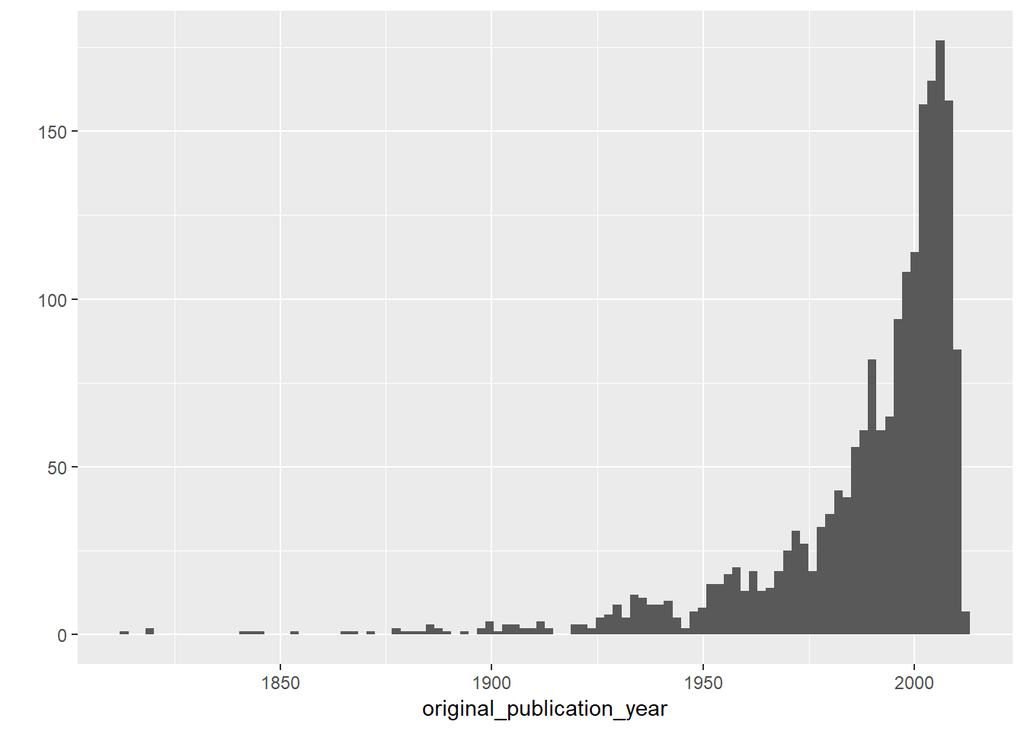

Observa-se que os títulos disponíveis na base concentram-se em livros de língua inglesa, abrangindo Canadá, Reino Unido e Estados Unidos. Há ainda 172 títulos cuja língua não foi especificada.

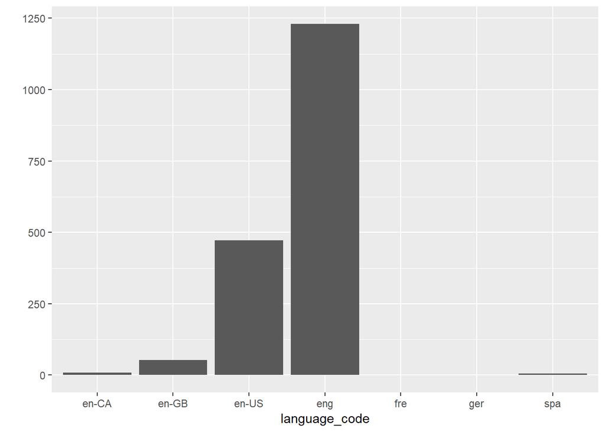

A maioria dos livros foram em média bem avaliados, com nota aproximada de 4 em uma escala que vai de 1 a 5:

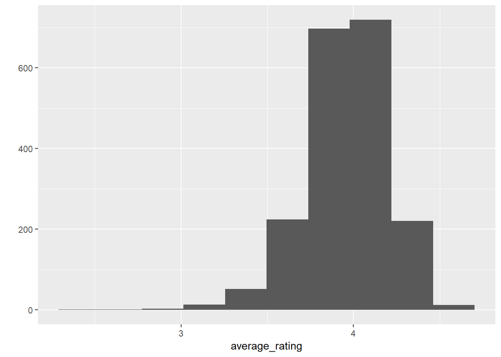

Não foi encontrada descrição sobre a diferença entre ratings_count e work_ratings_count, mas os gráficos abaixo indicam similaridade. O último gráfico, que é baseado na razão entre ratings_count e work_ratings_count confirma isto, com a maior parte dos livros tendo ratings_count pelo menos 80% do valor de work_ratings_count:

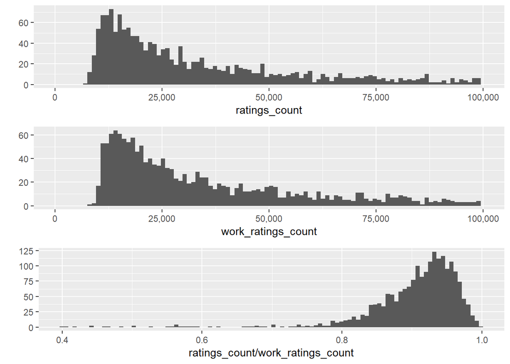

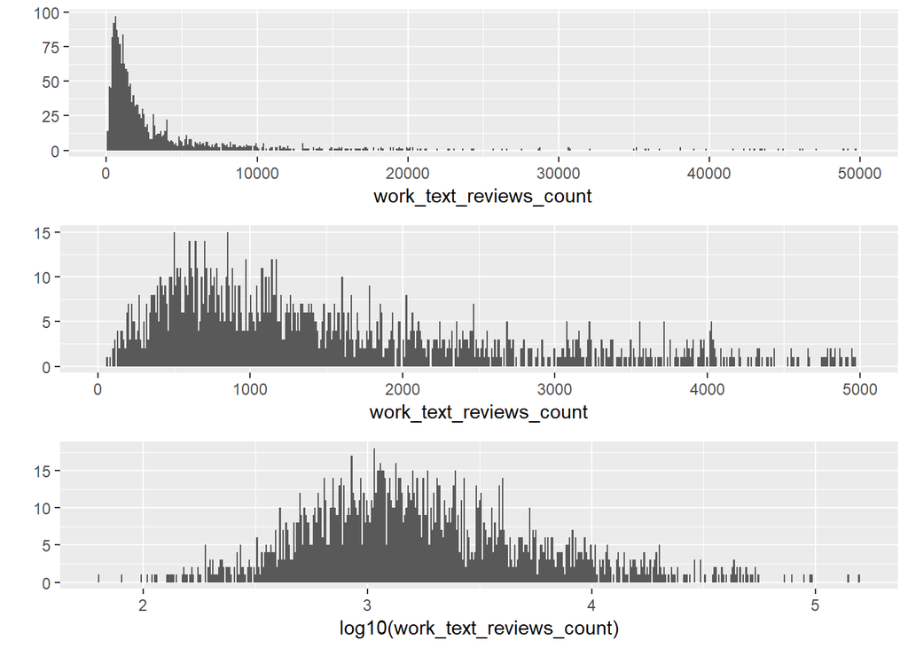

### Quais são os principais atributos de interesse deste conjunto de dados?

Entendo que os atributos mais interessantes para o objetivo do relatório são:

- o gênero principal;
- o resumo de cada livro (summary).

### Quais outros atributos você acha que podem lhe auxiliar na investigação destes atributos de interesse?

Aliado aos atributos citados acima, a média das avaliações (average_rating) e as quantidades de avaliações (work_ratings_count) e de reviews (work_text_reviews_count) se mostram interessantes como controle, evitando que um gênero sobreponha outros simplesmente por a base conter mais livros dele.

### Você criou novas variáveis a partir dos atributos existentes no conjunto de dados?

Sim, foram criadas a partir dos atributos de avaliações em conjunto com o gênero principal: genre_1_median_rating, genre_1_mean_ratings_count e genre_1_freq.

### Dos atributos investigados, distribuições incomuns foram encontradas? Você aplicou operações nos dados para limpá-los, ajustá-los ou mudar a forma dos dados? Se sim, por quê?

Não foram encontradas distribuições inesperadas, ainda que tenham sido aplicadas operações para melhor visualizar alguns casos.

# Seção de Gráficos Bivariados

Considerando apenas livros cuja quantidade de avaliações fosse superior a 79.414 (terceiro quartil), o gráfico abaixo apresenta a média da quantidade de avaliacoes por gênero:

```
##    Min. 1st Qu.  Median    Mean 3rd Qu.    Max.
##    8375   18814   34222  104690   79414 4942365
```

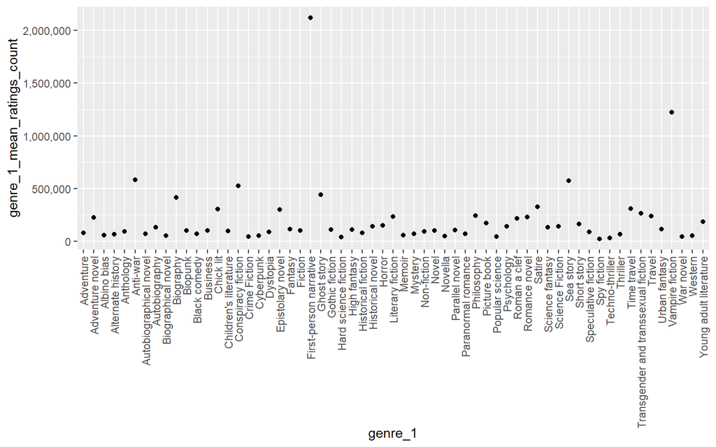

Pelo gráfico acima, é possível ver que alguns gêneros destacam-se. Fazendo um novo corte, para melhorar a visualização, desta vez pela mediana de genre_1_mean_ratings_count, temos:

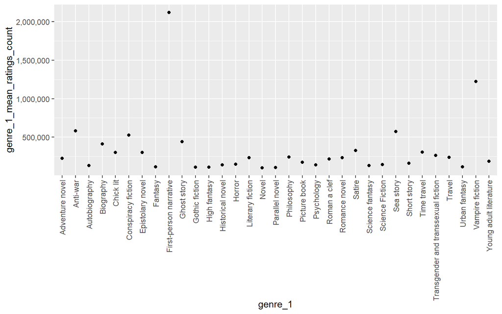

Acima percebe-se que entre os livros com maior quantidade de avaliações têm destaque os gêneros Narrativa em Primeira Pessoa e Ficção com Vampiros, seguidos pelos gêneros Anti-guerra, Biografia, Conspiração, História com Fantasmas e Histórias em Mar.

Abaixo foram criadas 3 visões comparativas entre gêneros principais e secundários, buscando entender suas relações. Vale observar especialmente os temas Ficção Científica e Fantasia, que possuem muitas relações:

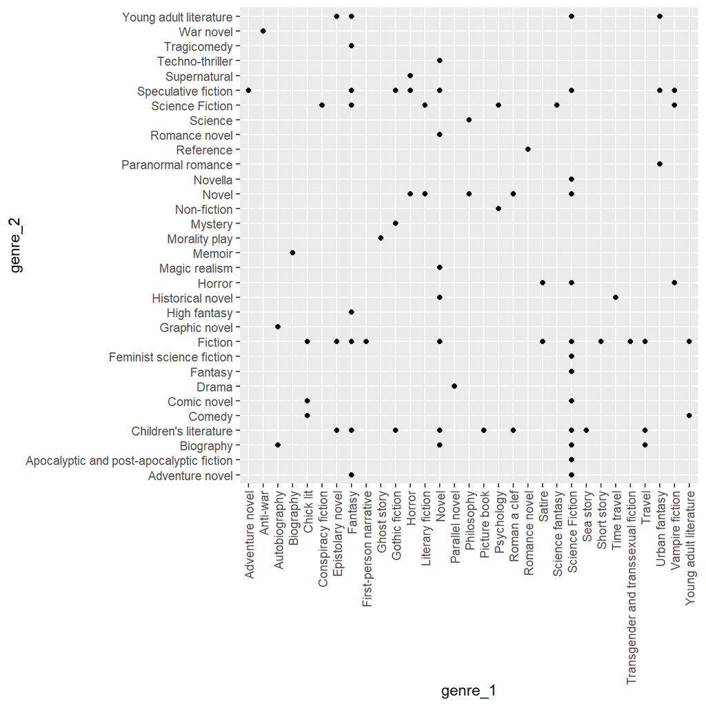

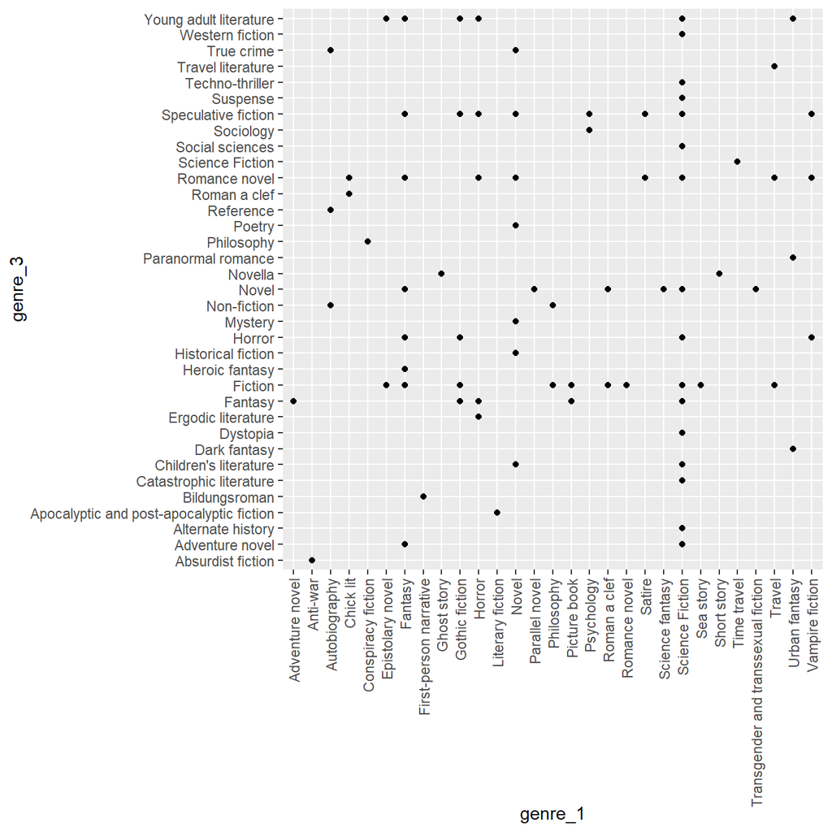

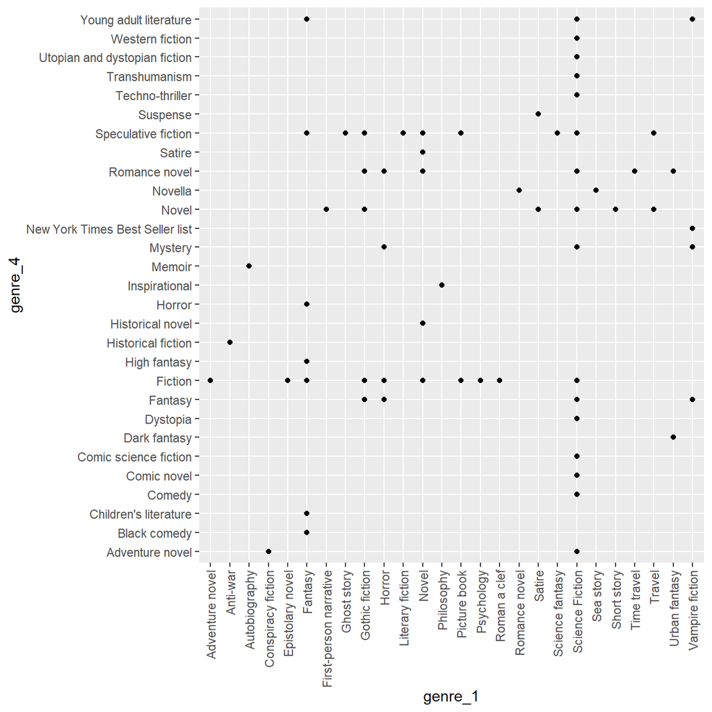

O gráfico tipo boxplot abaixo permite ver a relação entre gênero e média de avaliações, ainda considerando os cortes supracitados. Percebe-se que os gêneros Ficção Científica e Fantasia estão entre os que possuem avaliações abaixo de 3,6, ao lado do gênero Biografia:

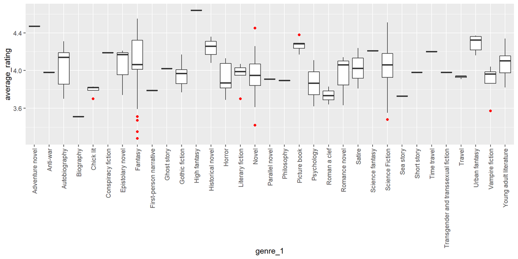

```
## $`Adventure novel`
##    Min. 1st Qu.  Median    Mean 3rd Qu.    Max.
##    4.47    4.47    4.47    4.47    4.47    4.47
##
## $`Anti-war`
##    Min. 1st Qu.  Median    Mean 3rd Qu.    Max.
##    3.98    3.98    3.98    3.98    3.98    3.98
##
## $Autobiography
##    Min. 1st Qu.  Median    Mean 3rd Qu.    Max.
##   3.700   3.855   4.140   4.034   4.190   4.310
##
## $Biography
##    Min. 1st Qu.  Median    Mean 3rd Qu.    Max.
##    3.51    3.51    3.51    3.51    3.51    3.51
##
## $`Chick lit`
##    Min. 1st Qu.  Median    Mean 3rd Qu.    Max.
##   3.700   3.790   3.820   3.792   3.822   3.830
##
## $`Conspiracy fiction`
##    Min. 1st Qu.  Median    Mean 3rd Qu.    Max.
##    4.19    4.19    4.19    4.19    4.19    4.19
##
## $`Epistolary novel`
##    Min. 1st Qu.  Median    Mean 3rd Qu.    Max.
##   3.740   3.955   4.170   4.040   4.190   4.210
##
## $Fantasy
##    Min. 1st Qu.  Median    Mean 3rd Qu.    Max.
##   3.280   4.013   4.065   4.043   4.322   4.550
##
## $`First-person narrative`
##    Min. 1st Qu.  Median    Mean 3rd Qu.    Max.
##    3.79    3.79    3.79    3.79    3.79    3.79
##
## $`Ghost story`
##    Min. 1st Qu.  Median    Mean 3rd Qu.    Max.
##    4.02    4.02    4.02    4.02    4.02    4.02
##
```

[output cut: 76 more lines]

```
## $Travel
##    Min. 1st Qu.  Median    Mean 3rd Qu.    Max.
##   3.910   3.925   3.940   3.930   3.940   3.940
##
## $`Urban fantasy`
##    Min. 1st Qu.  Median    Mean 3rd Qu.    Max.
##   4.160   4.218   4.325   4.293   4.362   4.370
##
## $`Vampire fiction`
##    Min. 1st Qu.  Median    Mean 3rd Qu.    Max.
##   3.570   3.862   3.965   3.885   3.987   4.040
##
## $`Young adult literature`
##    Min. 1st Qu.  Median    Mean 3rd Qu.    Max.
##   3.820   3.975   4.105   4.080   4.155   4.340
```

A título de curiosidade, foi verificada a relação entre o tamanho do título com a mediana das avaliações médias recebidas, sem grandes surpresas:

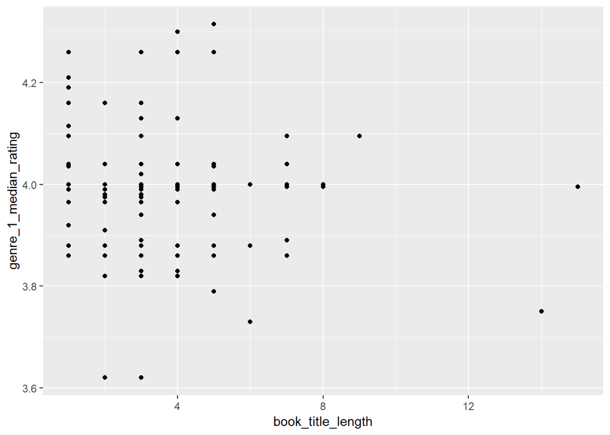

Abaixo seguem as correlações entre atributos:

```
##                            original_publication_year average_rating
## original_publication_year                 1.00000000     0.03562125
## average_rating                            0.03562125     1.00000000
## ratings_count                            -0.03890938     0.07714274
## work_ratings_count                       -0.04642058     0.08309026
## work_text_reviews_count                   0.13790034     0.09069003
## ratings_1                                -0.01112684    -0.20202834
## ratings_2                                -0.02230179    -0.23213916
## ratings_3                                -0.03791860    -0.12334758
## ratings_4                                -0.04310402     0.08881035
## ratings_5                                -0.05330037     0.21917127
## genre_1_median_rating                     0.05092561     0.41007389
## genre_1_mean_ratings_count               -0.13464105    -0.13540463
## genre_1_freq                             -0.02444026     0.04029751
## book_title_length                        -0.07414653     0.01433473
##                            ratings_count work_ratings_count
## original_publication_year    -0.03890938        -0.04642058
## average_rating                0.07714274         0.08309026
## ratings_count                 1.00000000         0.99424032
## work_ratings_count            0.99424032         1.00000000
## work_text_reviews_count       0.87592127         0.88480337
## ratings_1                     0.68446167         0.67305073
## ratings_2                     0.80952704         0.80730242
## ratings_3                     0.93440608         0.94174209
## ratings_4                     0.97438203         0.98606609
## ratings_5                     0.96646882         0.97059945
## genre_1_median_rating        -0.10056514        -0.09892037
## genre_1_mean_ratings_count    0.32482718         0.31356346
## genre_1_freq                 -0.03822643        -0.02351429
## book_title_length             0.01421682         0.01336113
##                            work_text_reviews_count   ratings_1   ratings_2
## original_publication_year             0.1379003358 -0.01112684 -0.02230179
## average_rating                        0.0906900256 -0.20202834 -0.23213916
## ratings_count                         0.8759212722  0.68446167  0.80952704
## work_ratings_count                    0.8848033726  0.67305073  0.80730242
## work_text_reviews_count               1.0000000000  0.49284967  0.64787996
## ratings_1                             0.4928496722  1.00000000  0.95070501
## ratings_2                             0.6478799556  0.95070501  1.00000000
## ratings_3                             0.8010599327  0.79895047  0.93216916
## ratings_4                             0.8900666541  0.57363644  0.74228038
```

[output cut: 50 more lines]

```
##                            book_title_length
## original_publication_year      -0.0741465306
## average_rating                  0.0143347267
## ratings_count                   0.0142168162
## work_ratings_count              0.0133611296
## work_text_reviews_count        -0.0007031518
## ratings_1                       0.0027906905
## ratings_2                       0.0315562228
## ratings_3                       0.0288845290
## ratings_4                       0.0118038107
## ratings_5                       0.0061146305
## genre_1_median_rating          -0.0867805889
## genre_1_mean_ratings_count      0.0654548143
## genre_1_freq                   -0.1104966973
## book_title_length               1.0000000000
```

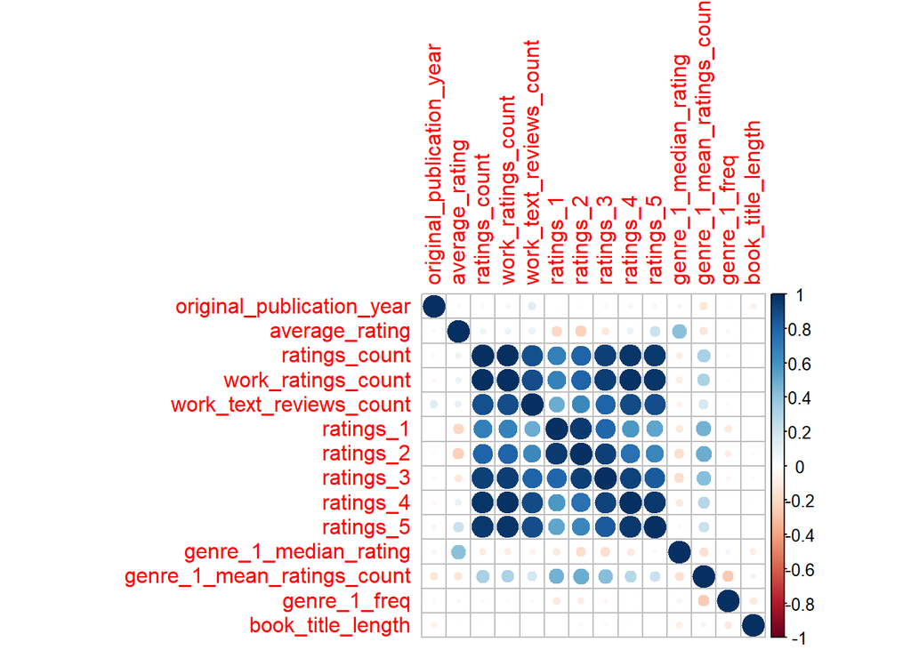

Percebe-se, portanto, correlação positiva principalmente entre a quantidade de avaliações, de reviews e de maiores notas (entre 4 e 5). Isto pode ser explicado pois, conforme visto anteriormente, a maioria dos livros da base possui avaliação próxima a 4.

# Análise Bivariada

### Discuta sobre alguns dos relacionamentos observados nesta parte da investigação. Como os atributos de interesse variaram no conjunto de dados?

Interessante também notar a relação entre gêneros principais e secundários, especialmente o gênero de Ficção com Vampiros, cujos gêneros relacionados foram Terror, Romance, Literatura jovem e Best Seller do New York Times.

### Você observou algum relacionamento interessante entre os outros atributos (os que não são de interesse)?

Sim, notou-se correlação positiva entre work_ratings_count e work_text_reviews_count, de 0.8848033726, o que era esperado, já que quanto mais avaliado um livro é, maior as chances de possuir mais reviews. Já com relação ao tamanho dos títulos (a minha curiosidade), praticamente não há correlação entre o tamanho dos títulos e a preferência dos leitores, já que todas as correlações com book_title_length foram próximas de zero. A com genre_1_median_rating, especificamente, foi de -0.08678059.

### Qual foi o relacionamento mais forte encontrado?

O esperado: ratings_count com work_ratings_count, com correlação de 0.99424032.

# Seção de Gráficos Multivariados

Partindo para o objetivo, que busca a relação de livros best sellers com gêneros e palavras contidas no resumo dos livros, foi criado novo dataframe contendo as 20 palavras mais comuns em cada gênero:

Também capturou-se as palavras mais frequentes para os livros com maior número de avaliações, os prováveis best-sellers:

A ideia aqui era, dadas as palavras mais frequentes por gênero, cruzá-las com as palavras mais frequentes dos livros mais avaliados, independente do gênero a que estes se referem, para obter a relação entre os dois:

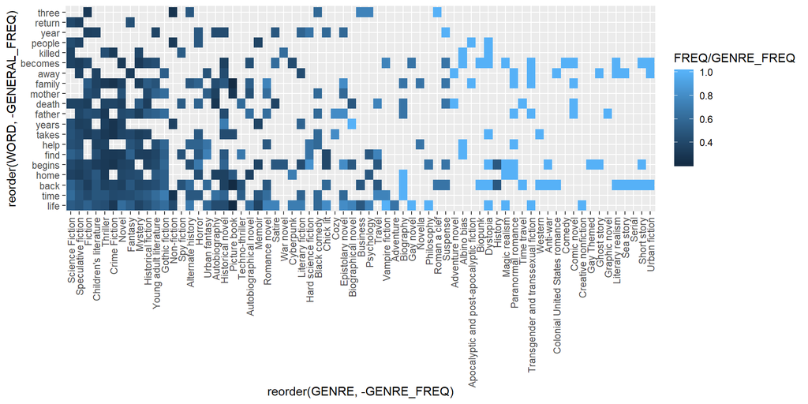

O gráfico acima contém:

- No eixo y, os temas mais comuns dos livros com maior número de avaliações, ordenados pelo número de vezes em que o tema aparece (quanto mais próximo da origem, maior sua ocorrência);
- No eixo x, em ordem decrescente de frequência na base, os gêneros;
- Nas cores, a razão da frequência observada para a palavra no gênero em relação à frequência do gênero na base.

# Análise Multivariada

### Discuta sobre os relacionamentos observados nesta parte da investigação. Quais atributos que fortaleceram os demais na observação das variáveis de interesse?

O cruzamento por si só, dos temas mais frequentes nos livros mais avaliados e dos gêneros com suas respectivas palavras mais frequentes, não estava muito elucidativo.

Utilizar a frequência das palavras no gênero (FREQ), a frequência das palavras no geral (GENERAL_FREQ) e a frequência do gênero na base (GENRE_FREQ) contribuíram na observação, permitindo identificar mais facilmente o objetivo deste relatório.

### Interações surpreendentes e/ou interessantes foram encontradas entre os atributos?

Interessante notar também a vigésima palavra: três, um número, muito frequente em diversas histórias infantis e na Bíblia.

# Gráficos Finais e Sumário

### Primeiro Gráfico

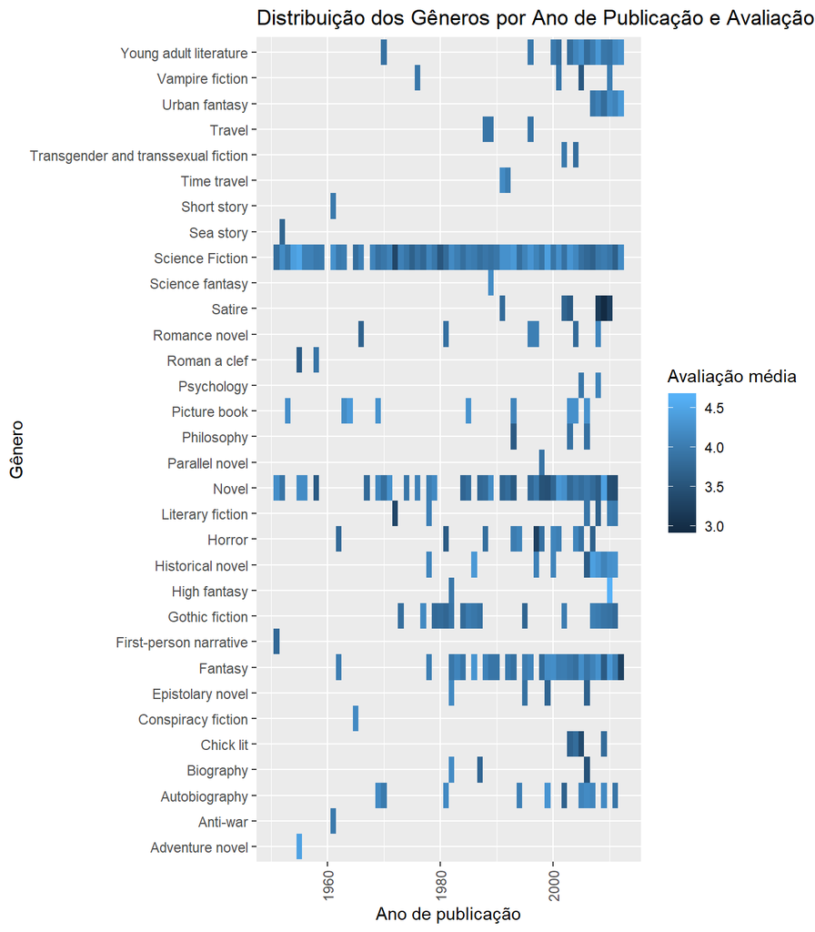

### Descrição do Primeiro Gráfico

O gráfico acima permite de uma só vez entender como os gêneros de livros mais avaliados (a partir do terceiro quartil) se distribuem em relação aos anos de publicação e às médias de avaliação.

É possível verificar que os gêneros Ficção científica mantem-se forte desde a década de 50. Ao mesmo tempo, livros de Fantasia passaram a ganhar mais atenção a partir da década de 80.

### Segundo Gráfico

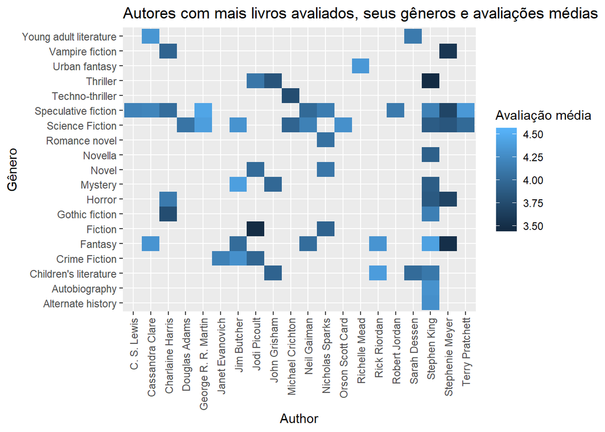

### Descrição do Segundo Gráfico

Este gráfico mostra, para os autores com mais de 9 livros entre os mais avaliados, qual o gênero e média de avaliações de seus livros.

### Terceiro Gráfico

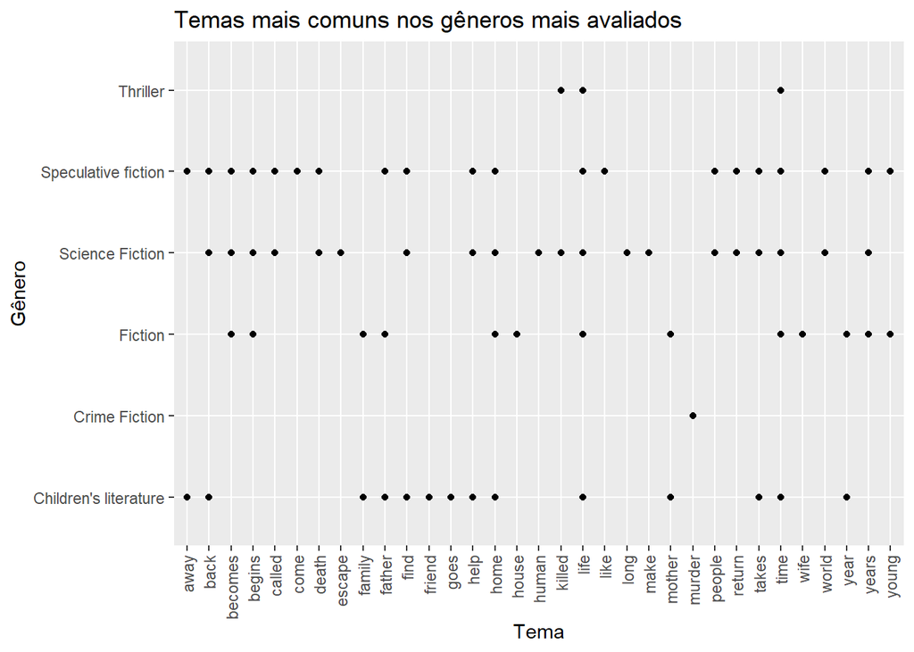

### Descrição do Terceiro Gráfico

O gráfico acima considera, para os livros mais avaliados, os temas mais comuns. Para melhor visualização, foram extraídos somente alguns dos gêneros e palavras, baseado nas suas frequências.

# Reflexão

Ainda que alguns gêneros estejam com pouca representação na base como um todo e as palavras tenham sido buscadas a partir dos resumos, as relações observadas já demonstram que, com uma base maior e todo o texto de cada livro, é possível desenvolver modelos a partir:

- de palavras e gêneros, para classificação automática de livros;
- de avaliações, temas e gêneros, para identificar com mais clareza o que conquista mais público (e buscar escrever sobre isso).

Enfim, gosto de escrever (já fiz dois livros de ficção e estou no terceiro:). O que posso dizer com certeza a partir deste estudo é que o ser humano prefere sim histórias fantasiosas, que lhe tirem da realidade e te tragam esperanças… ou ao menos um bom suspense e mistério. Acontece que, mesmo com esse desejo, inevitavelmente chegamos sempre aos mesmos temas, que são verdadeiramente os que mais nos importam e intrigam: família e vida.